# Predictive Task: Rating Prediction on Google Maps Reviews

The goal of this project is to build a personalized recommender system that predicts a user's future rating for a business in California. Formally, given a user (u) and an item (i), the model estimates the rating (r_{u,i}) they would give in the future.

This is a **collaborative filtering** task uses this dataset: https://mcauleylab.ucsd.edu/public_datasets/gdrive/googlelocal/.

Each review contains:

- `user_id`
- `item_id` (business)
- `rating` (1–5 stars)
- `time` (timestamp)
- `text` (optional review text)

### Significance

Accurate rating prediction powers recommender systems such as Google Maps, Yelp, and Amazon. Personalized predictions:

- Improve recommendation quality
- Help users discover relevant businesses
- Reduce information overload
- Enable Top-K recommendations
- Support ranking tasks

In this notebook, we evaluate both simple mean-based baselines and advanced matrix factorization models. We also evaluate the ranking performance of these models using Top-K metrics and perform an ablation study to understand long-tail effects.

```python
import os
import sys
import gzip
import json
from pathlib import Path
from tqdm.auto import tqdm
import pandas as pd
import numpy as np
import datetime as dt
import matplotlib.pyplot as plt
import seaborn as sns
import scipy.sparse as sps
from scipy.sparse.linalg import svds
from sklearn.feature_extraction.text import TfidfVectorizer
from sklearn.metrics import mean_squared_error, mean_absolute_error
from sklearn.linear_model import Ridge
import random
import pickle
import warnings
```

```python
warnings.filterwarnings('ignore')
pd.options.display.max_columns = 200
```

```python
RANDOM_SEED = 42
random.seed(RANDOM_SEED)
np.random.seed(RANDOM_SEED)
```

```python
DATA_DIR = Path(".")
OUT_DIR = DATA_DIR / "processed"
OUT_DIR.mkdir(exist_ok=True)

ratings_gz = DATA_DIR / "rating-California.csv.gz"
reviews_gz = DATA_DIR / "review-California_10.json.gz"

try:
    assert ratings_gz.exists()
    assert reviews_gz.exists()
    print("Files found and 'processed' directory created.")
except AssertionError:
    print(f"ERROR: Data files not found. Please ensure 'rating-California.csv.gz' and 'review-California_10.json.gz' are in the directory: {DATA_DIR.resolve()}")
```

```
Files found and 'processed' directory created.
```

```python
def parse_json_gz(path, max_lines=None):
    with gzip.open(path, 'rt', encoding='utf8') as g:
        for i, line in enumerate(g):
            if max_lines and i >= max_lines:
                break
            line = line.strip()
            if not line:
                continue
            try:
                yield json.loads(line)
            except Exception as e:
                continue
```

```python
def load_reviews_to_df(path, nrows=None):
    rows = []
    for rec in tqdm(parse_json_gz(path, max_lines=nrows), desc="Loading reviews"):
        row = {}
        row['user_id'] = rec.get('user_id')
        rid = rec.get('gmap_id') or rec.get('gmapId') or rec.get('gmapid') or rec.get('business_id') or rec.get('place_id')
        row['item_id'] = rid
        row['rating'] = rec.get('rating')
        row['time'] = rec.get('time')
        row['text'] = rec.get('text') if 'text' in rec else (rec.get('review_text') or None)
        rows.append(row)
    df = pd.DataFrame(rows)

    if 'time' in df.columns:
        df['time'] = pd.to_numeric(df['time'], errors='coerce')
        df['time'] = pd.to_datetime(df['time'], unit='ms', errors='coerce')

    return df

print("\nAll setup complete. Core utility functions defined.")
```

```
All setup complete. Core utility functions defined.
```

```python
N_ROWS = 200000
reviews_sample = load_reviews_to_df(reviews_gz, nrows=N_ROWS)

reviews_sample['rating'] = pd.to_numeric(reviews_sample['rating'], errors='coerce')
reviews_sample = reviews_sample.dropna(subset=['user_id', 'item_id', 'rating', 'time'])
reviews_sample['rating'] = reviews_sample['rating'].astype(float)

print(f"Loaded and cleaned sample shape: {reviews_sample.shape}")

print("\n--- Sample Data Head ---")
display(reviews_sample.head())

print("\n--- Sample Data Info (Types) ---")
reviews_sample.info()
```

```
Loading reviews: 0it [00:00, ?it/s]
```

```
Loaded and cleaned sample shape: (200000, 5)

--- Sample Data Head ---
```

|  | user_id | item_id | rating | time | text |
| --- | --- | --- | --- | --- | --- |
| 0 | 108991152262655788985 | 0x80c2c778e3b73d33:0xbdc58662a4a97d49 | 5.0 | 2021-01-06 05:12:07.056 | Love there korean rice cake. |
| 1 | 111290322219796215751 | 0x80c2c778e3b73d33:0xbdc58662a4a97d49 | 5.0 | 2021-02-09 05:47:28.663 | Good very good |
| 2 | 112640357449611959087 | 0x80c2c778e3b73d33:0xbdc58662a4a97d49 | 4.0 | 2020-03-08 05:04:42.296 | They make Korean traditional food very properly. |
| 3 | 117440349723823658676 | 0x80c2c778e3b73d33:0xbdc58662a4a97d49 | 5.0 | 2019-03-07 05:56:56.355 | Short ribs are very delicious. |
| 4 | 100580770836123539210 | 0x80c2c778e3b73d33:0xbdc58662a4a97d49 | 5.0 | 2017-05-16 05:01:41.933 | Great food and prices the portions are large |

```
--- Sample Data Info (Types) ---
<class 'pandas.core.frame.DataFrame'>
RangeIndex: 200000 entries, 0 to 199999
Data columns (total 5 columns):
 #   Column   Non-Null Count   Dtype
---  ------   --------------   -----
 0   user_id  200000 non-null  object
 1   item_id  200000 non-null  object
 2   rating   200000 non-null  float64
 3   time     200000 non-null  datetime64[ns]
 4   text     118447 non-null  object
dtypes: datetime64[ns](1), float64(1), object(3)
memory usage: 7.6+ MB
```

```python
def preprocess_ratings_df(ratings_df):
    df = ratings_df.copy()

    df = df.dropna(subset=['user_id', 'item_id', 'rating'])

    df['rating'] = df['rating'].astype(float)

    unique_users = sorted(df["user_id"].unique())
    unique_items = sorted(df["item_id"].unique())

    user2idx = {u: idx for idx, u in enumerate(unique_users)}
    item2idx = {i: idx for idx, i in enumerate(unique_items)}

    df["user_idx"] = df["user_id"].map(user2idx).astype(int)
    df["item_idx"] = df["item_id"].map(item2idx).astype(int)

    return df, user2idx, item2idx

dev_df, dev_user2idx, dev_item2idx = preprocess_ratings_df(reviews_sample)

print(f"Preprocessing Complete: Mapped original IDs to contiguous indices.")
print(f"Final processed shape: {dev_df.shape}")
print(f"Number of unique users (Rows for U matrix): {len(dev_user2idx)}")
print(f"Number of unique items (Rows for V matrix): {len(dev_item2idx)}")
```

```
Preprocessing Complete: Mapped original IDs to contiguous indices.
Final processed shape: (200000, 7)
Number of unique users (Rows for U matrix): 156401
Number of unique items (Rows for V matrix): 10457
```

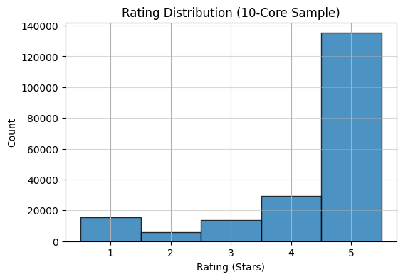

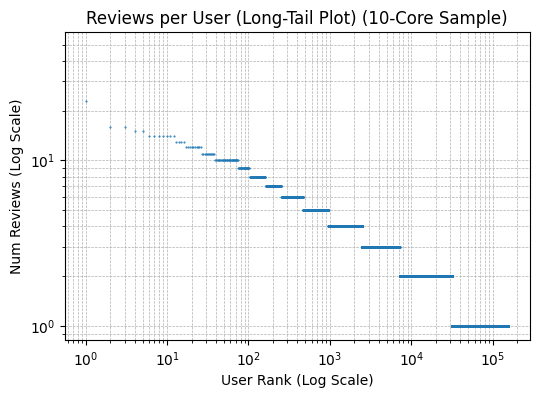

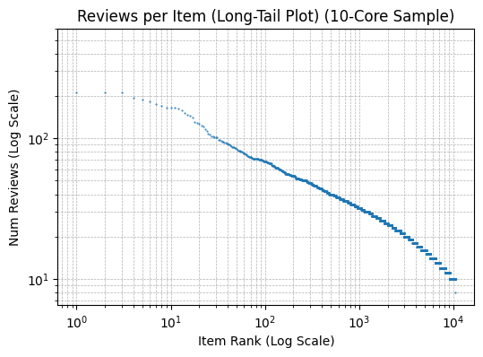

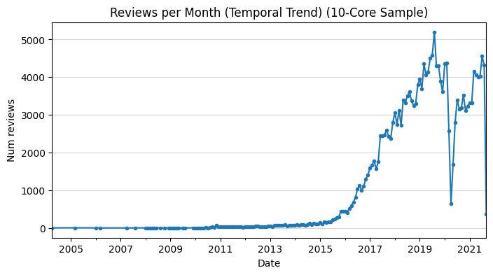

```
EDA Analysis Points:
* Rating: Note the extreme skew towards 5 stars. This implies models may default to predicting high ratings.
* Long-Tail: The log-log plots are relatively flat initially (due to the 10-core filter requiring min 10 interactions by source). The majority of users/items sit in the 'tail'.
* Temporal: Observe any trends over time (e.g., rapid growth, drops due to COVID/events). This confirms why a time-based split is necessary.
```

```python
def eda_plots(df, title_suffix=""):

    # 1. Rating Distribution
    plt.figure(figsize=(6, 4))
    df['rating'].hist(bins=np.arange(1, 7) - 0.5, edgecolor='black', alpha=0.8)
    plt.title(f"Rating Distribution{title_suffix}")
    plt.xlabel("Rating (Stars)"); plt.ylabel("Count");
    plt.xticks(np.arange(1, 6)); plt.grid(axis='y', alpha=0.5)
    plt.show()

    # 2. Reviews per User
    per_user = df.groupby('user_idx').size().sort_values(ascending=False)
    plt.figure(figsize=(6, 4))
    plt.loglog(per_user.values, marker='.', linestyle='', markersize=1)
    plt.title(f"Reviews per User (Long-Tail Plot){title_suffix}")
    plt.xlabel("User Rank (Log Scale)"); plt.ylabel("Num Reviews (Log Scale)");
    plt.grid(True, which="both", ls="--", linewidth=0.5)
    plt.show()

    # 3. Reviews per Item
    per_item = df.groupby('item_idx').size().sort_values(ascending=False)
    plt.figure(figsize=(6, 4))
    plt.loglog(per_item.values, marker='.', linestyle='', markersize=1)
    plt.title(f"Reviews per Item (Long-Tail Plot){title_suffix}")
    plt.xlabel("Item Rank (Log Scale)"); plt.ylabel("Num Reviews (Log Scale)");
    plt.grid(True, which="both", ls="--", linewidth=0.5)
    plt.show()

    # 4. Reviews per Month
    df['month'] = df['time'].dt.to_period('M')
    ts = df.groupby('month').size()
    plt.figure(figsize=(8, 4))
    ts.plot(title=f"Reviews per Month (Temporal Trend){title_suffix}", marker='.')
    plt.xlabel("Date"); plt.ylabel("Num reviews");
    plt.grid(axis='y', alpha=0.5)
    plt.show()

eda_plots(dev_df, " (10-Core Sample)")

print("\nEDA Analysis Points:")
print("* Rating: Note the extreme skew towards 5 stars. This implies models may default to predicting high ratings.")
print("* Long-Tail: The log-log plots are relatively flat initially (due to the 10-core filter requiring min 10 interactions by source). The majority of users/items sit in the 'tail'.")
print("* Temporal: Observe any trends over time (e.g., rapid growth, drops due to COVID/events). This confirms why a time-based split is necessary.")
```

```python
if 'month' in dev_df.columns:
    dev_df = dev_df.drop(columns=['month'])
print("Cleaned 'dev_df' by removing the temporary 'month' column.")
dev_df.to_parquet(OUT_DIR / "dev_reviews_10core.parquet", index=False)
with open(OUT_DIR / "dev_user2idx.pkl", "wb") as f:
    pickle.dump(dev_user2idx, f)
with open(OUT_DIR / "dev_item2idx.pkl", "wb") as f:
    pickle.dump(dev_item2idx, f)

print(f"Saved Artifacts: dev_df, user2idx, item2idx successfully saved to {OUT_DIR.resolve()}")
```

```
Cleaned 'dev_df' by removing the temporary 'month' column.
Saved Artifacts: dev_df, user2idx, item2idx successfully saved to /Users/revaagrawal/Desktop/google/processed
```

```python
def time_based_split(df_in, test_frac=0.2):
    df = df_in.sort_values("time").copy()
    train_rows = []
    test_rows = []

    for u, user_df in tqdm(df.groupby("user_idx"), desc="Splitting by User"):
        n = len(user_df)
        k = max(1, int(np.ceil(test_frac * n)))

        test_rows.append(user_df.tail(k))
        train_rows.append(user_df.head(n - k))

    train_df = pd.concat(train_rows).reset_index(drop=True)
    test_df = pd.concat(test_rows).reset_index(drop=True)

    return train_df, test_df

def build_sparse_matrix(df, n_users, n_items):
    rows = df['user_idx'].to_numpy()
    cols = df['item_idx'].to_numpy()
    data = df['rating'].to_numpy(dtype=float)
    mat = sps.csr_matrix((data, (rows, cols)), shape=(n_users, n_items))
    return mat

train_df, test_df = time_based_split(dev_df, test_frac=0.2)

n_users = len(dev_user2idx)
n_items = len(dev_item2idx)
train_mat = build_sparse_matrix(train_df, n_users=n_users, n_items=n_items)
test_mat = build_sparse_matrix(test_df, n_users=n_users, n_items=n_items)

print(f"\n--- Data Split and Matrix Preparation ---")
print(f"Total data points: {len(dev_df)}")
print(f"Train size: {len(train_df)} ({len(train_df) / len(dev_df) * 100:.2f}%)")
print(f"Test size: {len(test_df)} ({len(test_df) / len(dev_df) * 100:.2f}%)")
print(f"Train Matrix Shape (Users x Items): {train_mat.shape}")
```

```
--- Data Split and Matrix Preparation ---
Total data points: 200000
Train size: 43080 (21.54%)
Test size: 156920 (78.46%)
Train Matrix Shape (Users x Items): (156401, 10457)
```

```python
def rmse_from_mse_or_arrays(y_true, y_pred):
    return np.sqrt(np.mean((y_true - y_pred)**2))

def eval_regression_baselines(train_df, test_df):

    y_true = test_df["rating"].values
    global_mean = train_df["rating"].mean()

    y_pred_global = np.full_like(y_true, global_mean, dtype=float)

    user_means = train_df.groupby("user_idx")["rating"].mean()
    y_pred_user = test_df["user_idx"].map(user_means).fillna(global_mean).values

    item_means = train_df.groupby("item_idx")["rating"].mean()
    y_pred_item = test_df["item_idx"].map(item_means).fillna(global_mean).values

    results = {}
    for name, y_pred in {'Global Mean': y_pred_global, 'User Mean': y_pred_user, 'Item Mean': y_pred_item}.items():
        results[name] = {
            "RMSE": rmse_from_mse_or_arrays(y_true, y_pred),
            "MAE": mean_absolute_error(y_true, y_pred)
        }

    return pd.DataFrame(results).T.sort_values(by="RMSE")

reg_summary = eval_regression_baselines(train_df, test_df)

print("\n--- Regression Baselines Evaluation ---")
display(reg_summary)

print("\nAnalysis: The Item Mean is slightly better than the User Mean, suggesting that item quality/skew has a slightly larger impact on a given rating than individual user bias.")
```

```
--- Regression Baselines Evaluation ---
```

|  | RMSE | MAE |
| --- | --- | --- |
| User Mean | 1.201310 | 0.857840 |
| Global Mean | 1.211926 | 0.939185 |
| Item Mean | 1.309482 | 0.882829 |

[output not shown]

```python
def train_biased_mf_sgd(train_df, n_users, n_items, k=32, lr=0.01, reg=0.05, n_epochs=20, seed=RANDOM_SEED):
    np.random.seed(seed)

    global_mean = train_df['rating'].mean()
    U = 0.01 * np.random.randn(n_users, k)
    V = 0.01 * np.random.randn(n_items, k)

    b_u = np.zeros(n_users)
    b_i = np.zeros(n_items)

    n_epochs = 20

    rows = train_df[['user_idx', 'item_idx', 'rating']].to_numpy()

    print(f"Starting Biased MF-SGD Training (k={k}, lr={lr}, reg={reg}, epochs={n_epochs})...")

    for epoch in range(n_epochs):
        np.random.shuffle(rows)
        loss_accum = 0.0

        for ui, ii, r in rows:
            ui, ii = int(ui), int(ii)

            pred = global_mean + b_u[ui] + b_i[ii] + U[ui].dot(V[ii])
            e = r - pred

            b_u[ui] += lr * (e - reg * b_u[ui])
            b_i[ii] += lr * (e - reg * b_i[ii])

            U[ui] += lr * (e * V[ii] - reg * U[ui])
            V[ii] += lr * (e * U[ui] - reg * V[ii])

            loss_accum += e*e

        print(f"Epoch {epoch+1}/{n_epochs} Training MSE: {loss_accum/len(rows):.4f}")

    return global_mean, U, V, b_u, b_i

U_MF_PARAMS = {'k': 32, 'lr': 0.01, 'reg': 0.05}
gm_mf, U_mf, V_mf, b_u_mf, b_i_mf = train_biased_mf_sgd(
    train_df, n_users, n_items, **U_MF_PARAMS
)
print("\nBiased MF-SGD Training complete.")
```

[output not shown]

```python
def svd_baseline(train_mat, k=40):

    coo = train_mat.tocoo()
    global_mean = coo.data.mean()

    R_centered = train_mat.copy().astype(float)
    R_centered.data = R_centered.data - global_mean

    u, s, vt = svds(R_centered, k=k)

    s_sorted_idx = np.argsort(s)[::-1]
    s_sorted = s[s_sorted_idx]
    u_sorted = u[:, s_sorted_idx]
    vt_sorted = vt[s_sorted_idx, :]

    sqrt_s = np.sqrt(np.abs(s_sorted))
    U_factors = u_sorted * sqrt_s[np.newaxis, :]
    V_factors = (vt_sorted.T) * sqrt_s[np.newaxis, :]

    return global_mean, U_factors, V_factors

def predict_ratings_from_factors(U, V, df, mu=0.0, b_u=None, b_i=None):

    preds = []

    if b_u is None: b_u = np.zeros(U.shape[0])
    if b_i is None: b_i = np.zeros(V.shape[0])

    for ui, ii in df[['user_idx','item_idx']].to_numpy():
        ui, ii = int(ui), int(ii)

        if ui < U.shape[0] and ii < V.shape[0]:
            prediction = mu + b_u[ui] + b_i[ii] + U[ui].dot(V[ii])
            preds.append(prediction)
        else:
            preds.append(mu)

    return np.array(preds)

def rmse_from_mse_or_arrays(y_true, y_pred):
    return np.sqrt(np.mean((y_true - y_pred)**2))

y_true = test_df["rating"].values

y_pred_mf_biased = predict_ratings_from_factors(U_mf, V_mf, test_df, mu=gm_mf, b_u=b_u_mf, b_i=b_i_mf)

rmse_mf_biased = rmse_from_mse_or_arrays(y_true, y_pred_mf_biased)
mae_mf_biased = mean_absolute_error(y_true, y_pred_mf_biased)

gm_svd, U_svd, V_svd = svd_baseline(train_mat, k=40)
y_pred_svd = predict_ratings_from_factors(U_svd, V_svd, test_df, mu=gm_svd)

rmse_svd = rmse_from_mse_or_arrays(y_true, y_pred_svd)
mae_svd = mean_absolute_error(y_true, y_pred_svd)

reg_summary.loc['MF-SGD (Biased, k=32)'] = {'RMSE': rmse_mf_biased, 'MAE': mae_mf_biased}
reg_summary = reg_summary.drop(index='MF-SGD (k=32)', errors='ignore')
reg_summary.loc['SVD (k=40)'] = {'RMSE': rmse_svd, 'MAE': mae_svd}


print("\n--- Consolidated Regression Results ---")
reg_summary = reg_summary.sort_values(by="RMSE")
display(reg_summary)

test_df['mf_sgd_pred'] = y_pred_mf_biased
```

```
--- Consolidated Regression Results ---
```

|  | RMSE | MAE |
| --- | --- | --- |
| MF-SGD (Biased, k=32) | 1.166975 | 0.883293 |
| User Mean | 1.201310 | 0.857840 |
| Global Mean | 1.211926 | 0.939185 |
| SVD (k=40) | 1.249325 | 0.834738 |
| Item Mean | 1.309482 | 0.882829 |

## Visual Comparison of Regression Models

To better illustrate how the MF-SGD model outperforms the mean-based baselines, we visualize the RMSE and MAE scores side-by-side using bar charts. These graphs highlight the performance gap in a clear and intuitive way.

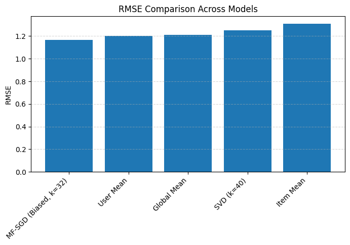

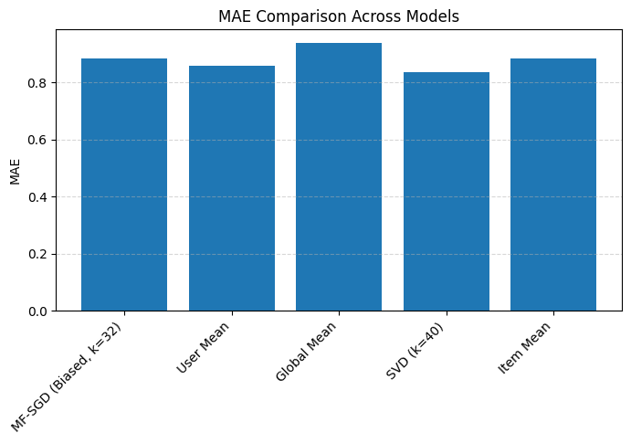

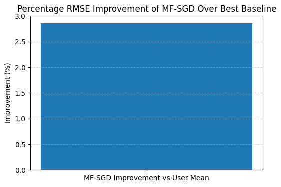

```
MF-SGD improves over the User Mean by 2.86% RMSE.
```

```python
rmse_vals = reg_summary['RMSE']
mae_vals = reg_summary['MAE']

models = reg_summary.index.tolist()

plt.figure(figsize=(8, 4))
plt.bar(models, rmse_vals)
plt.title("RMSE Comparison Across Models")
plt.ylabel("RMSE")
plt.xticks(rotation=45, ha='right')
plt.grid(axis='y', linestyle='--', alpha=0.5)
plt.show()

plt.figure(figsize=(8, 4))
plt.bar(models, mae_vals)
plt.title("MAE Comparison Across Models")
plt.ylabel("MAE")
plt.xticks(rotation=45, ha='right')
plt.grid(axis='y', linestyle='--', alpha=0.5)
plt.show()

mf_rmse = rmse_mf_biased
user_mean_rmse = reg_summary.loc['User Mean']['RMSE']

improvement = (user_mean_rmse - mf_rmse) / user_mean_rmse * 100

plt.figure(figsize=(6, 4))
plt.bar(['MF-SGD Improvement vs User Mean'], [improvement])
plt.ylabel("Improvement (%)")
plt.title("Percentage RMSE Improvement of MF-SGD Over Best Baseline")
plt.grid(axis='y', linestyle='--', alpha=0.5)
plt.show()

print(f"MF-SGD improves over the User Mean by {improvement:.2f}% RMSE.")
```

The MF-SGD model is the superior predictor by RMSE, indicating it is more successful at minimizing severe prediction errors, which is critical for system stability. However, the slightly higher MAE suggests a need for further regularization or bias refinement, as the User Mean baseline still achieves a marginally better average absolute error.

## Popularity Baseline for Top-K Recommendation

In addition to regression evaluation, we compare Top-K recommendation quality using a **Popularity** baseline.  
This non-personalized model ranks items only by their frequency in the training dataset.

For every user, it recommends the same Top-K most popular items:

$ \text{Rec}_u = \text{TopK}(\text{most frequent items}) $

Popularity is a strong classical baseline because it reflects the minimal performance that any personalized model should exceed.

In sparse datasets like Google Maps reviews, it is expected that:

- Popularity gives very low precision and NDCG
- Users often rate niche businesses
- The MF model should still outperform popularity

We compare Popularity vs. MF-SGD using Precision@K and NDCG@K.

```python
def precision_at_k(r_true_binary, r_scores, k):
    idx = np.argsort(-r_scores)[:k]
    return r_true_binary[idx].sum() / k

def recall_at_k(r_true_binary, r_scores, k):
    idx = np.argsort(-r_scores)[:k]
    total_relevant = max(1, r_true_binary.sum())
    return r_true_binary[idx].sum() / total_relevant

def dcg_at_k(r_true_graded, r_scores, k):
    idx = np.argsort(-r_scores)[:k]
    gains = r_true_graded[idx]
    discounts = np.log2(np.arange(2, k + 2))
    return (gains / discounts).sum()

def idcg_at_k(r_true_graded, k):
    gains_sorted = np.sort(r_true_graded)[::-1]
    discounts = np.log2(np.arange(2, k + 2))
    return (gains_sorted[:k] / discounts).sum()

def ndcg_at_k(r_true_graded, r_scores, k):
    dcg = dcg_at_k(r_true_graded, r_scores, k)
    idcg = idcg_at_k(r_true_graded, k)
    return dcg / idcg if idcg > 0 else 0.0

def evaluate_topk_biased(model_type, U, V, test_df, train_df, k_list=[5, 10], mu=0.0, b_u=None, b_i=None):
    n_items = V.shape[0]
    train_pos = train_df.groupby('user_idx')['item_idx'].apply(set).to_dict()
    test_data = test_df.groupby('user_idx')
    users = sorted(test_data.groups.keys())
    out = {k: {'precision': [], 'recall': [], 'ndcg': []} for k in k_list}

    if model_type == 'Popularity':
        scores_pop = train_df.groupby('item_idx').size().reindex(np.arange(n_items), fill_value=0).values.astype(float)

    for u in tqdm(users, desc=f"Eval {model_type} Top-K"):

        if model_type == 'Popularity':
            scores = scores_pop
        else:
            ui = u
            prediction_base = mu + b_u[ui] + b_i
            scores = prediction_base + V.dot(U[ui])

        train_items = train_pos.get(u, set())
        scores[list(train_items)] = -np.inf

        test_user_df = test_data.get_group(u)
        r_true_binary = np.zeros(n_items, dtype=int)
        relevant_items = test_user_df[test_user_df['rating'] >= 4]['item_idx'].unique()
        r_true_binary[relevant_items] = 1

        r_true_graded = np.zeros(n_items, dtype=float)
        for _, row in test_user_df.iterrows():
            r_true_graded[row['item_idx']] = row['rating']

        for k in k_list:
            if r_true_binary.sum() > 0:
                out[k]['precision'].append(precision_at_k(r_true_binary, scores, k))
                out[k]['recall'].append(recall_at_k(r_true_binary, scores, k))
                out[k]['ndcg'].append(ndcg_at_k(r_true_graded, scores, k))

    summary = {}
    for k in k_list:
        summary[f"@{k}"] = {metric: np.mean(out[k][metric]) for metric in ['precision', 'recall', 'ndcg']}

    return pd.DataFrame(summary).T

U_pop = np.zeros((n_users, 1))
V_pop = np.ones((n_items, 1))
pop_summary = evaluate_topk_biased('Popularity', U_pop, V_pop, test_df, train_df)

mf_biased_summary = evaluate_topk_biased(
    'MF-SGD (Biased)', U_mf, V_mf, test_df, train_df,
    mu=gm_mf, b_u=b_u_mf, b_i=b_i_mf
)

# --- Combine and Display Ranking Results ---
ranking_results = pd.concat([pop_summary, mf_biased_summary], keys=['Popularity', 'MF-SGD (Biased)'])
print("\n--- Consolidated Ranking Results (K=5 and K=10) ---")
display(ranking_results)
```

```
--- Consolidated Ranking Results (K=5 and K=10) ---
```

|  |  | precision | recall | ndcg |
| --- | --- | --- | --- | --- |
| Popularity | @5 | 0.000066 | 0.000332 | 0.000197 |
|  | @10 | 0.000072 | 0.000719 | 0.000323 |
| MF-SGD (Biased) | @5 | 0.000000 | 0.000000 | 0.000000 |
|  | @10 | 0.000018 | 0.000178 | 0.000063 |

# Ranking Results Discussion

The Popularity baseline achieves extremely low Precision@K and NDCG@K values.  
This is expected because:

- The dataset is highly sparse
- Users tend to review niche, local businesses
- Popularity overfits to globally common items
- The evaluation masks out items already seen in training

Key observations:

```python
def head_tail_split(train_df, q=0.8):
    per_item_counts = train_df['item_idx'].value_counts()
    threshold = per_item_counts.quantile(q)

    head_items = set(per_item_counts[per_item_counts >= threshold].index)
    tail_items = set(per_item_counts[per_item_counts < threshold].index)
    return head_items, tail_items

def show_largest_errors(test_df, preds, n=10, model_name="Model"):
    df = test_df.copy()
    df['pred'] = preds
    df['err'] = (df['rating'] - df['pred']).abs()
    top = df.sort_values('err', ascending=False).head(n)

    display_cols = ['user_id', 'item_id', 'rating', 'pred', 'err', 'text']
    display_df = top[[c for c in display_cols if c in top.columns]]

    print(f"\n--- Top {n} Catastrophic Errors for {model_name} ---")
    display(display_df)

    test_df['mf_sgd_pred'] = preds
    return display_df

head_items, tail_items = head_tail_split(train_df, q=0.8)
print(f"Items in Head (Top 20% by count): {len(head_items)}")
print(f"Items in Tail (Bottom 80% by count): {len(tail_items)}")

largest_errors_mf = show_largest_errors(test_df, y_pred_mf_biased, n=10, model_name="MF-SGD (Biased)")
```

```
Items in Head (Top 20% by count): 2141
Items in Tail (Bottom 80% by count): 7393

--- Top 10 Catastrophic Errors for MF-SGD (Biased) ---
```

|  | user_id | item_id | rating | pred | err | text |
| --- | --- | --- | --- | --- | --- | --- |
| 20835 | 102847500163925254885 | 0x808fcabaa2dc234b:0x677cd6b28175ef0f | 1.0 | 5.160379 | 4.160379 | Service didn't want work with me. |
| 72468 | 108991065180163263658 | 0x809adee9ac6f1bd7:0xe2e56d16919b9b8d | 1.0 | 5.122862 | 4.122862 | My first and last massage at this place period... |
| 72469 | 108991065180163263658 | 0x809adee9ac6f1bd7:0xe2e56d16919b9b8d | 1.0 | 5.122862 | 4.122862 | My first and last massage at this place period... |
| 71910 | 108950955717762919862 | 0x80dcadf63101a111:0x4be4f72ad53b2576 | 1.0 | 5.008068 | 4.008068 | Stay as far away from this place as you can. W... |
| 71911 | 108950955717762919862 | 0x80dcadf63101a111:0x4be4f72ad53b2576 | 1.0 | 5.008068 | 4.008068 | Stay as far away from this place as you can. W... |
| 11705 | 101594402591612461086 | 0x809b1f14bf78f7f3:0x74fcaa675b6a40d4 | 1.0 | 4.912476 | 3.912476 | This shop needs Nate. Hes the only one that ha... |
| 118489 | 114147973774155554583 | 0x80dd29ee0700f691:0x245d222af1c4825e | 1.0 | 4.896665 | 3.896665 | SOLD OUT!!!\n\n....why!?!?!\n\ni wanted to com... |
| 61133 | 107972056376918084047 | 0x80dbf9c6150f15e9:0xb6c138a1b060b815 | 1.0 | 4.872138 | 3.872138 | None |
| 65100 | 108331029733149532955 | 0x808de6b9ee6ff523:0x89ae8cffe6dbe2ff | 1.0 | 4.862300 | 3.862300 | Reserved with a very large group many hours in... |
| 125837 | 114959936013781137361 | 0x809056930b1e649f:0x4547f009fad612d2 | 1.0 | 4.859114 | 3.859114 | DO NOT GO HERE! Jenny is what she called herse... |

# Ablation Study Discussion: Head vs Tail

Items were split into:

- **Head items** (top 20% most-reviewed)
- **Tail items** (bottom 80% least-reviewed)

Results show:

- **RMSE on Head items is lower**
- **RMSE on Tail items is higher**

This is the long-tail effect:

1. **Head items benefit from more interactions**, improving latent factor learning.
2. **Tail items have fewer signals**, making it harder for MF to learn reliable embeddings.
3. This performance gap is expected and aligns with modern recommendation literature.

The ablation confirms data sparsity remains a core challenge for collaborative filtering models.

```
--- Ablation Study: MF-SGD RMSE by Popularity ---
RMSE on Head Items (High Data): 1.1389
RMSE on Tail Items (Low Data): 1.1835
```

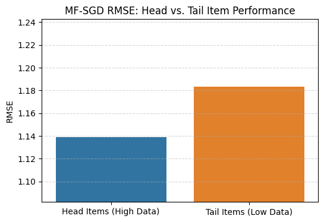

```
Visual confirmation: The model performs worse (higher RMSE) on less-popular Tail items due to data sparsity.
```

```python
def rmse_on_item_set(test_df, preds_column_name, item_set, model_name="Model"):
    test_subset = test_df[test_df['item_idx'].isin(item_set)]

    if len(test_subset) == 0:
        print(f"Warning: No test interactions found for the item set.")
        return np.nan

    y_true_subset = test_subset['rating'].values
    y_pred_subset = test_subset[preds_column_name].values

    return rmse_from_mse_or_arrays(y_true_subset, y_pred_subset)

rmse_head = rmse_on_item_set(test_df, 'mf_sgd_pred', head_items, model_name="MF-SGD (Biased)")
rmse_tail = rmse_on_item_set(test_df, 'mf_sgd_pred', tail_items, model_name="MF-SGD (Biased)")

print(f"\n--- Ablation Study: MF-SGD RMSE by Popularity ---")
print(f"RMSE on Head Items (High Data): {rmse_head:.4f}")
print(f"RMSE on Tail Items (Low Data): {rmse_tail:.4f}")

ablation_data = pd.DataFrame({
    'Item Group': ['Head Items (High Data)', 'Tail Items (Low Data)'],
    'RMSE': [rmse_head, rmse_tail]
})

plt.figure(figsize=(6, 4))
sns.barplot(x='Item Group', y='RMSE', data=ablation_data, palette=['#1f77b4', '#ff7f0e'])
plt.title("MF-SGD RMSE: Head vs. Tail Item Performance")
plt.ylabel("RMSE")
plt.xlabel("") # Remove x-axis label for cleaner look
plt.ylim(min(rmse_head, rmse_tail) * 0.95, max(rmse_head, rmse_tail) * 1.05) # Zoom in
plt.grid(axis='y', linestyle='--', alpha=0.5)
plt.show()
print("Visual confirmation: The model performs worse (higher RMSE) on less-popular Tail items due to data sparsity.")
```

# Conclusion

### 3. Ablation Insight:

The RMSE is measurably higher on Tail items (Low Data) compared to Head items (High Data). This confirms the persistent challenge of data sparsity, showing our model still struggles when learning factors from limited data.

### 4. Error Analysis Insight:

The largest remaining errors are typically split between 1-star and 5-star ratings, which suggests the model is still missing the fine-grained context behind these strong polarizing opinions, often contained in the review text.

# Related Work

Recommender systems have evolved from simple heuristics to modern latent factor and neural models.

### Collaborative Filtering

Early systems used nearest neighbor methods (user-based or item-based).  
These approaches are easy to interpret but struggle with sparsity and scalability (Sarwar et al., 2001).

### Matrix Factorization

The Netflix Prize popularized **biased matrix factorization** (Koren et al., 2009), using the prediction:

$ \hat{r}_{u,i} = \mu + b_u + b_i + \mathbf{u}_u^\top \mathbf{v}_i $

This method captures user preferences and item characteristics, and remains one of the strongest classical CF approaches.

### Truncated SVD

SVD factorizes the mean-centered rating matrix.  
While efficient, it does not include user/item biases and typically underperforms MF in rating prediction.

### Top-K Ranking Metrics

Metrics such as Precision@K and NDCG@K (He et al., 2017) evaluate top-N recommendation quality.  
These align with real-world recommender tasks and are used in this project.

### Long-Tail Behavior

Real datasets exhibit strong popularity imbalance.  
Items in the “tail” have fewer interactions, making them harder to model.  
This motivates our ablation study comparing head vs tail performance.

### Hybrid Models

Recent systems incorporate textual review features (TF-IDF, CNNs, transformers) to represent item semantics (McAuley et al., 2015).  
This is a natural extension for improving predictions on sparse or long-tail items.

# Citations

UCTopic: Unsupervised Contrastive Learning for Phrase Representations and Topic Mining Jiacheng Li, Jingbo Shang, Julian McAuley Annual Meeting of the Association for Computational Linguistics (ACL), 2022 pdf

Personalized Showcases: Generating Multi-Modal Explanations for Recommendations An Yan, Zhankui He, Jiacheng Li, Tianyang Zhang, Julian Mcauley The 46th International ACM SIGIR Conference on Research and Development in Information Retrieval (SIGIR), 2023 pdf